# R Refresher: Notebooks, Notation and Visualization

# Making PDFs using R Markdown

We can also create PDF files from .Rmd files by changing the output option in the header from “html_notebook” to “pdf_document”.

We can suppress code, output, warnings, messages, or errors using chunk options, e.g. echo=FALSE will hide this code chunk.

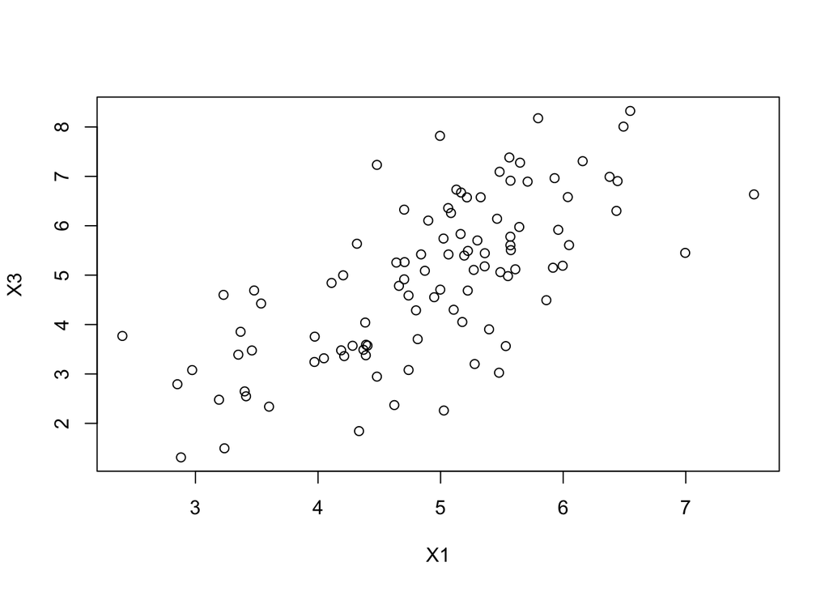

Set a chunk to not evaluate using `eval=FALSE` and it will not evaluate it when you run the entire script from start to finish.

```r
# example plot using the base plotting function
# ----------
plot(x = X1,
     y = X3)
```

There are similar options to suppress messages, warnings, and errors, which may be useful for homework.

# How to export from RStudio Cloud and save onto your own computer

If you’re working on RStudio Cloud and would like to download your files:

1. Check the file you’d like to export and the click More > Export in the File viewer. It will download to your computer’s downloads folder.
2. You may want to Export slides as a PDF or MS Word document. To do that, you first need to change “slidy_presentation” to “pdf_document” or “word_document” in the file header (line 5 of the file, under output:). Note that you might also have to change some of the file structure to ensure correct formatting.
3. Word documents then automatically download when you Knit them. PDF documents can be exported from the File viewer by following step 1.

# Latex symbols and useful math equations for Causal Inference

Insert inline math symbols between dollar signs, e.g. $Y_{ij}$ or $P(Y = 1)$.

We can also insert chunks of math spanning multiple lines between double dollar signs:

$$\mathbb{E}[Y | X = x] \\
\mathbb{E}[Y | X]$$

Use two dollar signs to insert sections of LaTeX (there are other options to insert these chunks as well). Use underscore (_) for subscript, carrot (^) for superscript, and a backslash to initiate special characters (greek letters, curly braces, etc). When the subscript or superscript is more than 1 character it is necessary to surround the content with curly braces.

For example, a simple MSM:

$$E_{U,X}(Y_a) = m(a | \beta)$$

You can also align equations within the dollar signs using the “aligned” environment and an ampersand, and double backslashes for line breaks using LaTex code. Note this will aligns equations by the “=” sign.

$$\begin{aligned}
E_{U,X}(Y_a) &= m(a | \beta) \\
E_{U,X}(Y_a) &= \beta_0 + \beta_1 a \\
\end{aligned}$$

We can think about an MSM as a projection of a true causal relationship onto some curve. Some important LaTeX tools for this are mathop, brackets, summation, and mathcal (for script A).

$$\beta(P_{U,X} | m) \equiv \mathop{argmin}_{\beta} E_{U,X} [ \sum_{a \in
\mathcal{A} } (Y_a - m(a|\beta))^2 ]$$

We can also include text within math equations. If we have many endogenous variables in W we might want to write something like:

$$\begin{aligned}
W & = (\text{age}, \text{sex}, \text{risk factors}) \\
A & = (\text{treatment}) \\
Y & = (\text{death within 5 years}) \\
\end{aligned}$$

Sometimes we need to render equations using set notation, such as $\in$, or using curly brackets.

$$\begin{aligned}
a & \in \mathcal{A} \\
\mathcal{A} &= \{ 0, 1 \}
\end{aligned}$$

We can use the `mathcal` operator to render symbols for the Causal Model $\mathcal{M}^F$ or the Causal Model augmented with additional assumptions required for identifiability $\mathcal{M}^{F*}$.

To denote that the observed data is drawn according to the observed data distribution $P_0$:

$$O = (W, A, Y) \sim P_0 \\$$

When we get to the estimation part of the course we may need to use a hat above symbol to indicate it is an estimate. This is similar to using “X bar” to represent the sample mean.

$$\begin{aligned}
\bar{X} \\
\hat{\Psi} \\
\end{aligned}$$

Target Causal Parameters, such as the Average Treatment Effect often denoted using $\Psi^F$, while statistical parameters are denoted $\Psi$. The connection between these will be made during the “Idenfitication” part of the course.

$$\begin{aligned}
\Psi^F(P_{U,X}) = E_{U,X}[Y_1 - Y_0] \\
\end{aligned}$$

To write that two random variables are independent or conditionally independent, use the perp operator, as in: $X \perp Z$ to indicate that the random variable is independent of Z.

# Review of Notation

## Observed Data - Review

Suppose we have $m$ independent individuals indexed by $i = 1 ... m$, each with observations $j = 1... n_i$. For each individual we measure 3 covariates.
$$\begin{aligned}
O_{i} &= (Y_{ij}, X_{ij1}, X_{ij2}, X_{ij3}, T_{ij})\ j =
1,...,n_i \\
O_{i} & \sim^{iid} P_{O} \\
\end{aligned}$$

Alternatively, we can collect the covariate information at each timepoint into a row vector $\mathbf{X}_{ij} = (X_{ij1}, X_{ij2}, X_{ij3}, T_{ij})$. Combining across $j=1,...n_i$ gives a matrix..

$$\begin{aligned}
O_{i} &= (Y_{ij}, \mathbf{X}_{ij})\ j = 1,...,n_i \\
O_{i} & \sim^{iid} P_{O} \\
\end{aligned}$$

## Variance and Covariance - Review

For a random variable $Y \sim P_Y$, the variance is defined as:

$$Var(Y) = E[(Y-E[Y])^2] = E[Y^2] - (E[Y])^2$$

And for two random variables $Y \sim P_Y$ and $X \sim P_X$, the covariance is defined as:

$$Cov(X, Y) = E[(X - E[X])(Y - E[Y])] = E[XY] - E[X]E[Y]$$
Note that this implies $Cov(Y, Y) = Var(Y)$.

For a random vector $Z = (Z_1, Z_2, Z_3)^T$, the Covariance Matrix is defined as:
$$\begin{bmatrix}
Var(Z_1) & Cov(Z_1, Z_2) & Cov(Z_1, Z_3) \\
Cov(Z_2, Z_1) & Var(Z_2, Z_2) & Cov(Z_2, Z_3) \\
Cov(Z_3, Z_1) & Cov(Z_3, Z_2) & Var(Z_3) \\
\end{bmatrix}$$

# Notation Example Problems

## Notation Exercise 1

We have $m = 50$ units of observation, $n_i = 12$ observations over time per unit, with the same timepoints used for each unit. At each time point one outcome and two covariates are measured. And there is one fixed covariate (i.e., constant over time) for each unit.

Question: Describe this data structure using the notation.

Solution:
$$O_i = (Y_{ij}, X_{ij1}, X_{ij2}, Z_i, T_{ij})\ j=1,...,12$$

We could also express this as a matrix. Note that $Z_i$ could be denoted $X_{ij3}$ in conjunction other notation indicating that it is constant over time. (Notation isn’t perfect).

## Notation Exercise 2

Suppose observed data consist of repeated over time (3 different times) observations of independent subjects, where at each time, 2 observations (measurements) are taken of an outcome and covariates, including the time of observation.

We could express this using $i$ for individuals, $j$ for time points, and $k$ for measurements within a timepoint.

$$\begin{aligned}
O_i &= (Y_{ijk}, \mathbf{X}_{ijk}, T_{ijk})\ j=1,...,3\ k \in (1,2)
\\
\mathbf{X}_{ijk} &\in \mathbb{R}_{2 n_i \times p} \\
\end{aligned}$$

Alternatively, we can avoid a separate index for $k$ and have $j=1,...,6$, where the index $j$ corresponds to the six measurements (3 time points, 2 measurements at each timepoint). The importance and use of this distinction could depend on whether we care about the order of the two observations at each timepoint.

$$\begin{aligned}
O_i &= (Y_{ij}, \mathbf{X}_{ij}, T_{ij})\ j=1,...,6 \\
\mathbf{X}_{ij} &\in \mathbb{R}_{n_i \times p} \\
\end{aligned}$$

## Notation Exercise 3

Provide Notation for the Following Additional Variance-Covariance structures for the outcome conditional on covariates:

1. All measurements are uncorrelated. All individuals have the same variance.

Solutions:

1. We can use a single number $\sigma^2$ to describe the variance of an individual outcome. Covariance between different observations is 0. (In other words, to covariance between any pair of different outcome measurements (conditional on the covariates) is zero).

$$\begin{aligned}
Var(Y_{ijk} | \mathbf{X}_{ijk}, T_{ijk}) &= \sigma^2 \\
Cov(e_{ijk}, e_{abc}) &= 0\ (i \neq a\ or\ j \neq b\ or\ k \neq
c)
\end{aligned}$$

Alternatively,

$$\begin{aligned}
Var(Y_{ij} | \mathbf{X}_{ij}, T_{ij}) &= \sigma^2 \\
Cov(e_{ij}, e_{ab}) &= 0\ (i \neq a\ or\ j \neq b)
\end{aligned}$$